# Biostats Project

2024-03-21

```r
library(readxl) #for loading Excel files
library(dplyr) #for data processing
library(here) #to set paths
library(tidyverse)
library(rstatix)
```

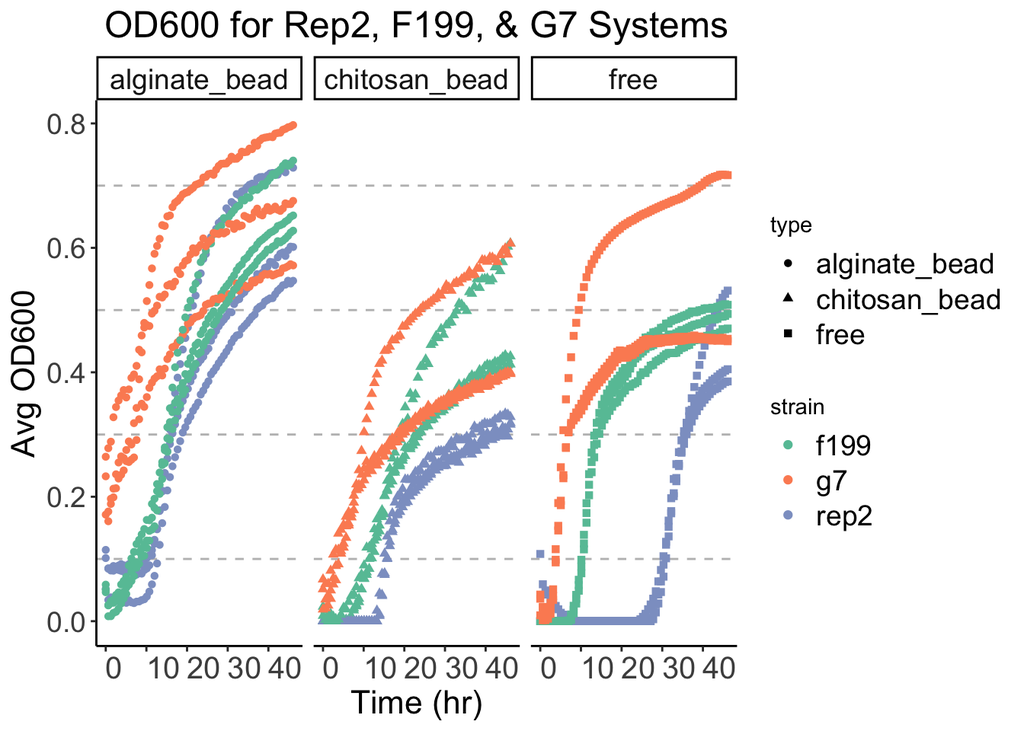

```r
#path to data
data_location <- here::here("data","odwells.xlsx")
data_location2 <- here::here("data","odwells_six.xlsx")
#load data.
data <- read_excel(data_location)
six <- read_excel(data_location2)

##What does the growth data look like?
ggplot(data = six, aes(x = time_h.x, y = blank_cor, color = strain, shape = type)) +
  geom_point() + theme_classic() + xlab("Time (hr)") + ylab("Avg OD600") +
  theme(panel.grid.minor.y = element_line(color = "grey", linetype = "dashed"),
        axis.text.x=element_text(angle = 0, hjust = 0, size = 15),
        axis.title = element_text(size = 16),
        axis.text.y = element_text(size = 14),
        legend.text = element_text(size = 14),
        plot.title = element_text(size = 18, hjust = 0.5),
        strip.text = element_text(size = 14)) +ggtitle("OD600 for Rep2, F199, & G7 Systems")+
  facet_wrap(~ type)+
  scale_color_brewer(palette="Set2")
```

```r
#Since we have 3 wells of each type and lots of time points, these graphs look messy. Let's see the averages of the wells
#data for average of 3 groups
glimpse(data)
```

```
## Rows: 666
## Columns: 7
## $ time_h.x  <dbl> 0.0000000, 0.0000000, 0.0000000, 0.0000000, 0.0000000, 0.000…
## $ type      <chr> "alginate_bead", "alginate_bead", "alginate_bead", "chitosan…
## $ sample    <chr> "b_f199_sa", "b_g7_sa", "b_rep2_sa", "b_f199_c", "b_g7_c", "…
## $ strain    <chr> "f199", "g7", "rep2", "f199", "g7", "rep2", "f199", "g7", "r…
## $ blank_cor <dbl> 0.052020000, 0.222803333, 0.089320000, 0.010692222, 0.045870…
## $ Strain    <chr> "F199", "G7", "Rep2", "F199", "G7", "Rep2", "F199", "G7", "R…
## $ Type      <chr> "Alginate Bead", "Alginate Bead", "Alginate Bead", "Chitosan…
```

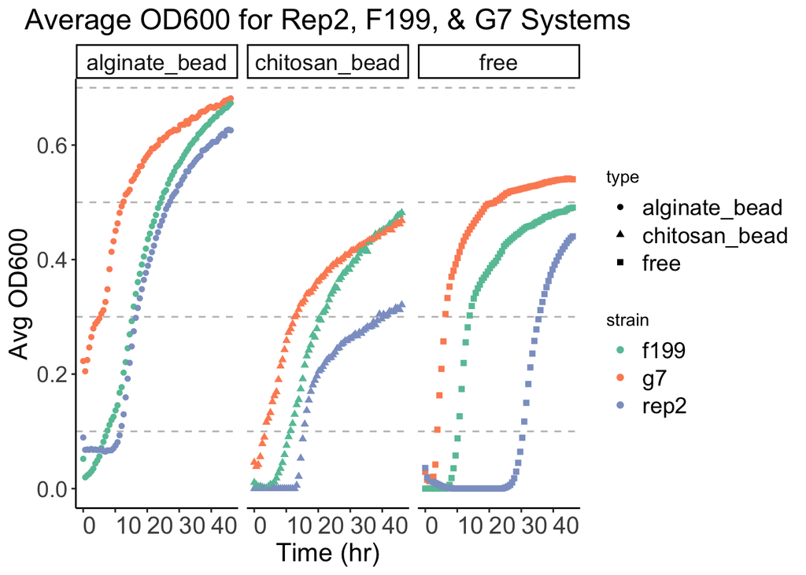

```r
data_minus<- data %>% dplyr::select(time_h.x, strain, type, sample, blank_cor)
ggplot(data = data_minus, aes(x = time_h.x, y = blank_cor, color = strain, shape = type)) +
  geom_point() + theme_classic() + xlab("Time (hr)") + ylab("Avg OD600") +
  theme(panel.grid.minor.y = element_line(color = "grey", linetype = "dashed"),
        axis.text.x=element_text(angle = 0, hjust = 0, size = 15),
        axis.title = element_text(size = 16),
        axis.text.y = element_text(size = 14),
        legend.text = element_text(size = 14),
        plot.title = element_text(size = 18, hjust = 0.5),
        strip.text = element_text(size = 14)) +ggtitle("Average OD600 for Rep2, F199, & G7 Systems")+
  facet_wrap(~ type)+
  scale_color_brewer(palette="Set2")
```

```r
#Now, let's try stats for the dataset with all individual subjects
glimpse(six)
```

```
## Rows: 1,998
## Columns: 10
## $ type           <chr> "alginate_bead", "alginate_bead", "alginate_bead", "alg…
## $ well           <chr> "A2", "A2", "A2", "A2", "A2", "A2", "A2", "A2", "A2", "…
## $ OD600          <dbl> 0.77926, 0.76278, 0.75928, 0.75899, 0.76206, 0.76017, 0…
## $ time_h.x       <dbl> 0.0000000, 0.6313889, 1.2627778, 1.8941667, 2.5255556, …
## $ sample         <chr> "b_rep2_sa", "b_rep2_sa", "b_rep2_sa", "b_rep2_sa", "b_…
## $ strain         <chr> "rep2", "rep2", "rep2", "rep2", "rep2", "rep2", "rep2",…
## $ time_h.y       <dbl> 0, 0, 0, 0, 0, 0, 0, 0, 0, 0, 0, 0, 0, 0, 0, 0, 0, 0, 0…
## $ control_sample <chr> "bb_sa", "bb_sa", "bb_sa", "bb_sa", "bb_sa", "bb_sa", "…
## $ OD600_b        <dbl> 0.67783, 0.67783, 0.67783, 0.67783, 0.67783, 0.67783, 0…
## $ blank_cor      <dbl> 0.10143, 0.08495, 0.08145, 0.08116, 0.08423, 0.08234, 0…
```

```r
six_minus<- six %>% dplyr::select(time_h.x, strain, type, sample, blank_cor, well)
anova_test(data=six_minus, dv=blank_cor, wid=well, within="time_h.x", between=c("strain", "type"))
```

```
## ANOVA Table (type II tests)
##
##                 Effect DFn  DFd       F         p p<.05   ges
## 1               strain   2   18  27.559  3.32e-06     * 0.699
## 2                 type   2   18  21.268  1.82e-05     * 0.642
## 3             time_h.x  73 1314 536.336  0.00e+00     * 0.878
## 4          strain:type   4   18   2.106  1.22e-01       0.262
## 5      strain:time_h.x 146 1314  23.173 1.06e-273     * 0.383
## 6        type:time_h.x 146 1314   9.527 9.78e-127     * 0.203
## 7 strain:type:time_h.x 292 1314   7.263 5.14e-142     * 0.280
```

With the ANOVA above, we see main effects and interactions. However, I’m not sure we can use this test because the data isn’t normally distributed. Let’s check that.

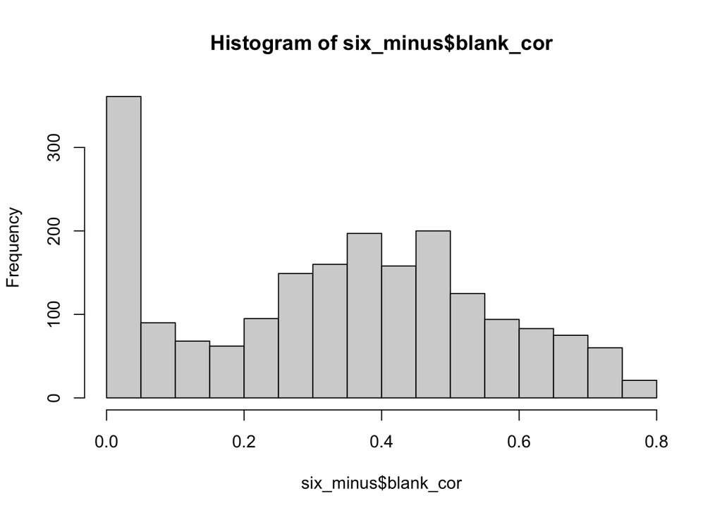

```r
hist(six_minus$blank_cor)
```

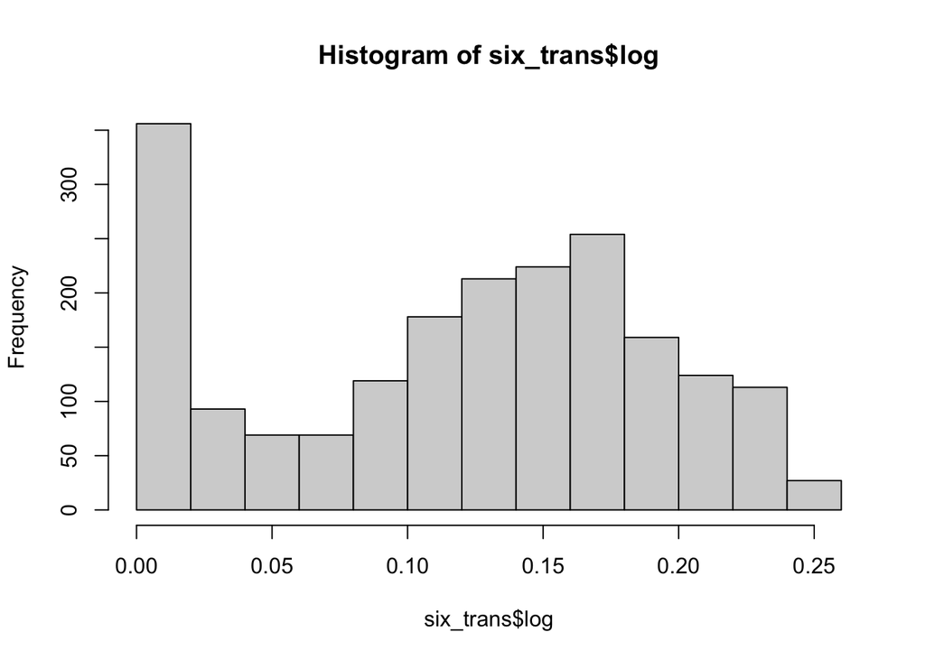

```r
#This shows us that our distribution does not look normal. There are lots of zero and near-zero values that skew this, especially since we have a bacterial strain with a long lag time.
#Can we transform via log to normalize this?
six_trans <- six_minus
six_trans$plus <- six_trans$blank_cor+1 #adding +1 since we have zero values
six_trans$log <- log10(six_trans$plus)
six_trans$sqrt <- six_trans$blank_cor**(1/2)

hist(six_trans$log) #still not normal
```

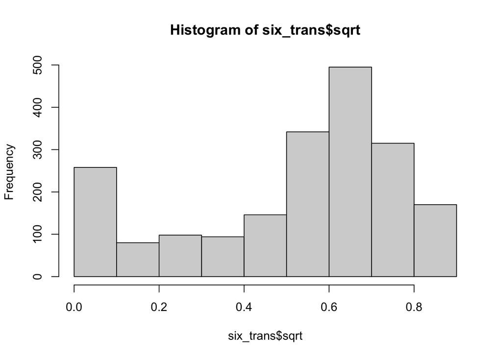

```r
hist(six_trans$sqrt) #still not normal
```

#G7 and F199 ANOVA These transformations aren’t normalizing the data. Let’s try truncating the data - we can infer lag time without all of the data present, so we don’t neccesarily need all of those near zero values

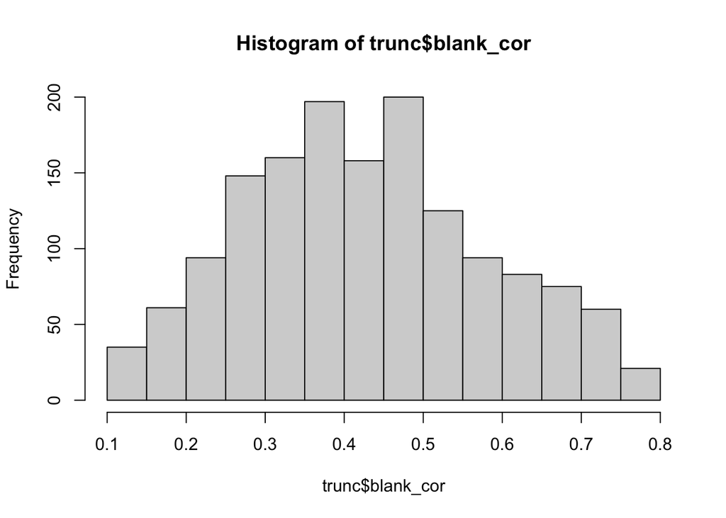

```r
trunc <- six_minus %>% filter(blank_cor>0.12) %>% filter(time_h.x>0.5)
hist(trunc$blank_cor) #now, this looks normal
```

```r
shapiro_test(trunc$blank_cor) #this still tells us it's not normal...is it becuase it's bound at zero?
```

```
## # A tibble: 1 × 3
##   variable        statistic  p.value
##   <chr>               <dbl>    <dbl>
## 1 trunc$blank_cor     0.985 1.41e-11
```

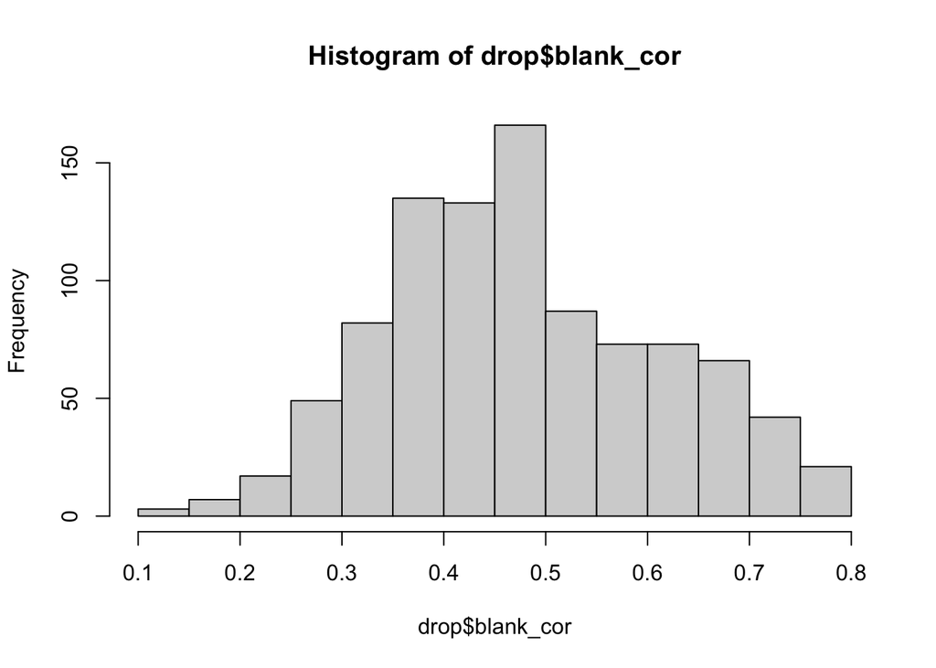

```r
#can we run anova on this dataset?
#anova_test(data=trunc, dv=blank_cor, wid=well, within="time_h.x", between=c("strain", "type"))
#getting contrast error. Let's try removing unsued variable, sample
trunc_minus <- trunc %>% dplyr::select(!sample)
#anova_test(data=trunc_minus, dv=blank_cor, wid=well, within="time_h.x", between=c("strain", "type"))
#getting contrast error. Seemed like problem could be that there aren't the same time points for all subjects. Let's check that
#maybe it would be easier to see "complete cases" for time if time was wide instead of long. let's try that
wide<-  trunc_minus %>% pivot_wider(names_from=time_h.x, values_from=blank_cor)
#this makes it easier to see missing cases. most come from rep2. Let's exclude it for now
drop<- trunc_minus %>% filter(strain != "rep2") %>% filter(time_h.x>13)
#see how this looks
wide_drop<-  drop %>% pivot_wider(names_from=time_h.x, values_from=blank_cor)
hist(drop$blank_cor) #looking normalish but slightly skewed. try shapiro test
```

```r
shapiro_test(drop$blank_cor)
```

```
## # A tibble: 1 × 3
##   variable       statistic      p.value
##   <chr>              <dbl>        <dbl>
## 1 drop$blank_cor     0.984 0.0000000155
```

```r
#now we have complete cases. let's try anova
anova_test(data=drop, dv=blank_cor, wid=well, within="time_h.x", between=c("strain", "type")) #this works!
```

```
## ANOVA Table (type II tests)
##
##                 Effect DFn DFd       F         p p<.05   ges
## 1               strain   1  12   2.902  1.14e-01       0.190
## 2                 type   2  12   7.015  1.00e-02     * 0.531
## 3             time_h.x  52 624 281.040  0.00e+00     * 0.429
## 4          strain:type   2  12   0.154  8.59e-01       0.024
## 5      strain:time_h.x  52 624  44.235 5.12e-175     * 0.106
## 6        type:time_h.x 104 624  11.994  9.97e-96     * 0.060
## 7 strain:type:time_h.x 104 624   3.383  5.31e-21     * 0.018
```

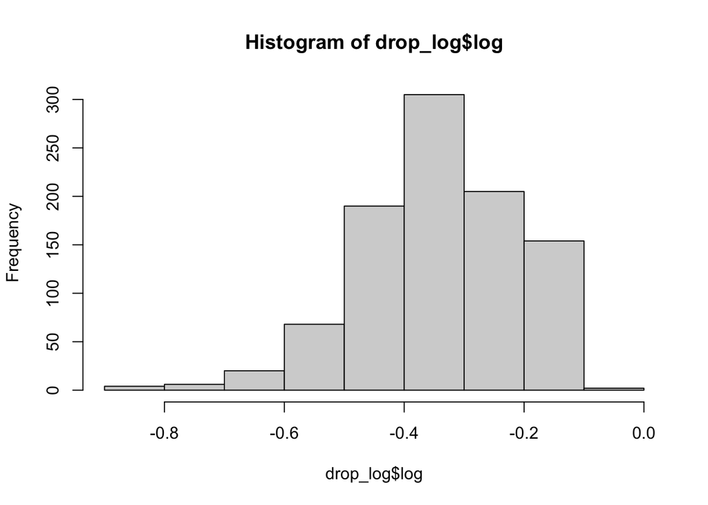

```r
#trying log(blank_cor) since shapiro test tells us this data is not normal
drop_log <- drop
drop_log$log <- log10(drop$blank_cor)
hist(drop_log$log)
```

```r
shapiro.test(drop_log$log) #still not normal...
```

```
##
##  Shapiro-Wilk normality test
##
## data:  drop_log$log
## W = 0.9737, p-value = 4.07e-12
```

#Rep2 ANOVA We got the ANOVA to work for g7 and f199 above - but we lost rep2. Can we analyze a small subset of data from later time point in order to test differences between rep2 and the others? Lets try

```r
view(wide) #for complete cases, we need time > 31 hours
rep<- trunc_minus %>% filter(time_h.x>31) #greatly reduces observations, but maybe we can still detect differences
anova_test(data=rep, dv=blank_cor, wid=well, within="time_h.x", between=c("strain", "type"))
```

```
## ANOVA Table (type II tests)
##
##                 Effect DFn DFd       F         p p<.05   ges
## 1               strain   2  18   6.089  1.00e-02     * 0.399
## 2                 type   2  18  17.896  5.26e-05     * 0.661
## 3             time_h.x  23 414 109.750 3.18e-160     * 0.102
## 4          strain:type   4  18   0.543  7.06e-01       0.106
## 5      strain:time_h.x  46 414  15.498  1.11e-64     * 0.031
## 6        type:time_h.x  46 414   4.467  5.53e-17     * 0.009
## 7 strain:type:time_h.x  92 414  13.631  2.22e-81     * 0.053
```

```r
glimpse(rep)
```

```
## Rows: 648
## Columns: 5
## $ time_h.x  <dbl> 31.56972, 32.20111, 32.83250, 33.46389, 34.09528, 34.72667, …
## $ strain    <chr> "rep2", "rep2", "rep2", "rep2", "rep2", "rep2", "rep2", "rep…
## $ type      <chr> "alginate_bead", "alginate_bead", "alginate_bead", "alginate…
## $ blank_cor <dbl> 0.67017, 0.68647, 0.68417, 0.69067, 0.69237, 0.69757, 0.7013…
## $ well      <chr> "A2", "A2", "A2", "A2", "A2", "A2", "A2", "A2", "A2", "A2", …
```

```r
#getting "between-subjects model is singular" error - try making factors
#rep$strain <- factor(rep$strain, levels = unique(rep$strain))
#rep$type <- factor(rep$type, levels = unique(rep$type))
#rep$well <- factor(rep$well, levels = unique(rep$well))
#anova_test(data=rep, dv=blank_cor, wid=well, within="time_h.x", between=c("strain", "type")) #still doesn't work
#wide_rep<-  rep %>% pivot_wider(names_from=time_h.x, values_from=blank_cor) #turns out problem was I set time at 30 instead of 31, so cases were incomplete. Have fixed this now and hashed
```

#visualizing truncated data

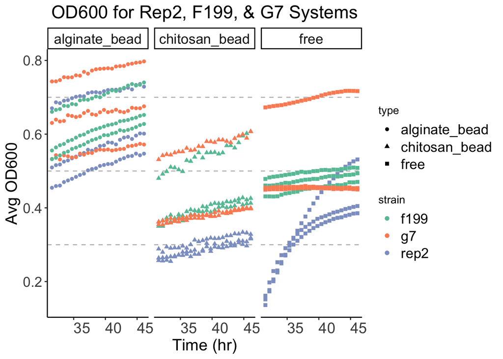

```r
ggplot(data = rep, aes(x = time_h.x, y = blank_cor, color = strain, shape = type)) +
  geom_point() + theme_classic() + xlab("Time (hr)") + ylab("Avg OD600") +
  theme(panel.grid.minor.y = element_line(color = "grey", linetype = "dashed"),
        axis.text.x=element_text(angle = 0, hjust = 0, size = 15),
        axis.title = element_text(size = 16),
        axis.text.y = element_text(size = 14),
        legend.text = element_text(size = 14),
        plot.title = element_text(size = 18, hjust = 0.5),
        strip.text = element_text(size = 14)) +ggtitle("OD600 for Rep2, F199, & G7 Systems")+
  facet_wrap(~ type)+
  scale_color_brewer(palette="Set2")
```

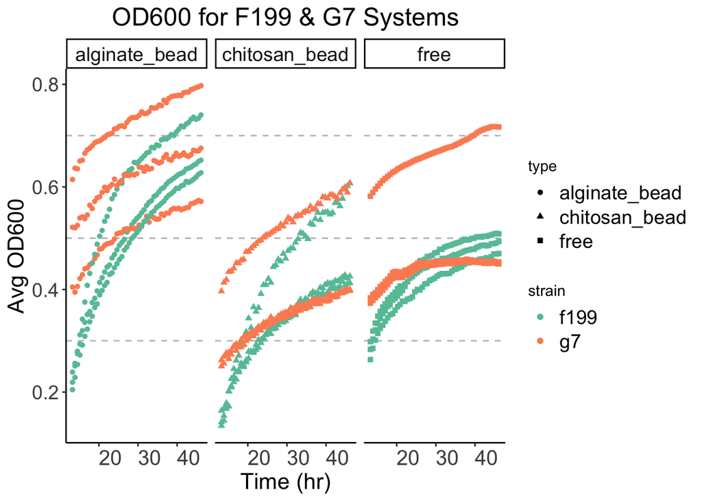

```r
#Here, we are just getting data from late growth stages. May not be the most informative. But, it could point to something interesting. For example, it would appear that encapsulation with the alginate bead "equalizes" the strain differences seen in the free systems, since those data points are closer together. Does that warrant further investigation?

ggplot(data = drop, aes(x = time_h.x, y = blank_cor, color = strain, shape = type)) +
  geom_point() + theme_classic() + xlab("Time (hr)") + ylab("Avg OD600") +
  theme(panel.grid.minor.y = element_line(color = "grey", linetype = "dashed"),
        axis.text.x=element_text(angle = 0, hjust = 0, size = 15),
        axis.title = element_text(size = 16),
        axis.text.y = element_text(size = 14),
        legend.text = element_text(size = 14),
        plot.title = element_text(size = 18, hjust = 0.5),
        strip.text = element_text(size = 14)) +ggtitle("OD600 for F199 & G7 Systems")+
  facet_wrap(~ type)+
  scale_color_brewer(palette="Set2")
```

I don’t love losing portions of the data when trucating, especially because it forces us to cut important parts (the log phase) of bacterial growth. What can we do with non-parametric tests looking at all of the data? #Non-parametric

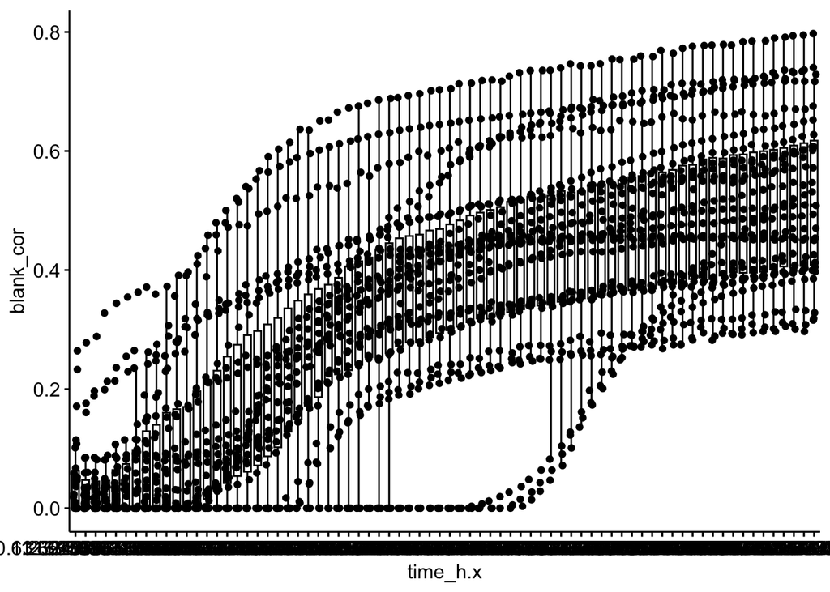

```r
#nonparametric alternative to RM ANOVA is Friedman test
library(ggpubr)
ggboxplot(six_minus, x = "time_h.x", y = "blank_cor", add = "jitter")
```

```r
res.fried <- six_minus %>% friedman_test(blank_cor ~ time_h.x |well) #like a RM ANOVA (one factor only)
res.fried # p = 0, no question of the effect of time (but that's obvious)
```

```
## # A tibble: 1 × 6
##   .y.           n statistic    df     p method
## * <chr>     <int>     <dbl> <dbl> <dbl> <chr>
## 1 blank_cor    27     1881.    73     0 Friedman test
```

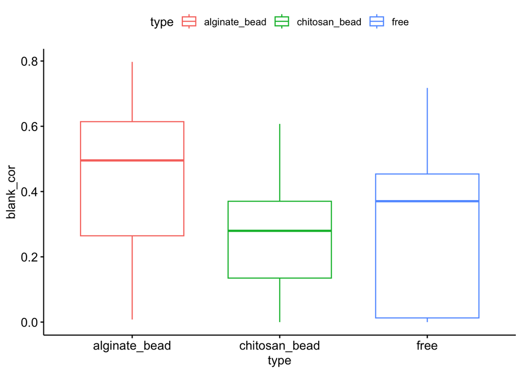

```r
#*sig effect of time (RM)
#pairwise comparisons with Wilcoxon signed rank
#pwc <- six_minus %>% wilcox_test(blank_cor ~ type, paired = TRUE, p.adjust.method = "bonferroni")
#pwc
#pwc_strain <- six_minus %>% wilcox_test(blank_cor ~ strain, paired = TRUE, p.adjust.method = "bonferroni")
#pwc_strain
#Wilcoxon doesn't apply here because I don't have paired samples, and I have more than two levels in my factors

ggboxplot(six_minus, x = "type", y = "blank_cor", color = "type")
```

```r
kruskal.test(blank_cor ~ type, data = six_minus) #*sig effect of type
```

```
##
##  Kruskal-Wallis rank sum test
##
## data:  blank_cor by type
## Kruskal-Wallis chi-squared = 286.41, df = 2, p-value < 2.2e-16
```

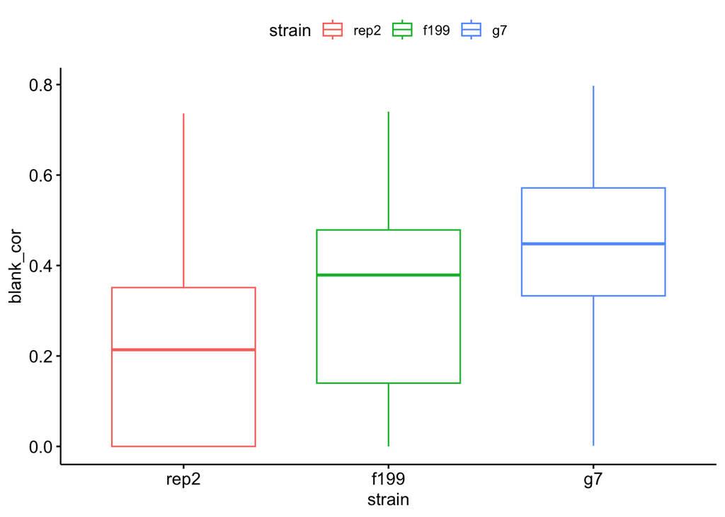

```r
ggboxplot(six_minus, x = "strain", y = "blank_cor", color = "strain")
```

```r
kruskal.test(blank_cor ~ strain, data = six_minus) #like a one-factor ANOVA by ranks
```

```
##
##  Kruskal-Wallis rank sum test
##
## data:  blank_cor by strain
## Kruskal-Wallis chi-squared = 339.62, df = 2, p-value < 2.2e-16
```

```r
#*sig effect of strain

#Looking at curves as a whole

#we could use the Kolmogorov-Smirnov Test to test whether samples come from same distribution
bead<- six_minus %>% filter(type == "alginate_bead") #need to separate into two groups (alginate bead vs free)
free<- six_minus %>% filter(type =="free")
ks.test(bead$blank_cor, free$blank_cor) #distributions are different p<2.2e-16
```

```
##
##  Two-sample Kolmogorov-Smirnov test
##
## data:  bead$blank_cor and free$blank_cor
## D = 0.38889, p-value < 2.2e-16
## alternative hypothesis: two-sided
```

```r
chitosan<- six_minus %>% filter(type == "chitosan_bead") #separate another group for another comparison
ks.test(bead$blank_cor, chitosan$blank_cor) #(alginate bead vs chitosan bead, *p<2.2e-16)
```

```
##
##  Two-sample Kolmogorov-Smirnov test
##
## data:  bead$blank_cor and chitosan$blank_cor
## D = 0.47898, p-value < 2.2e-16
## alternative hypothesis: two-sided
```

```r
ks.test(free$blank_cor, chitosan$blank_cor) #(chitosan bead vs blank, p<2.2e-16)
```

```
##
##  Two-sample Kolmogorov-Smirnov test
##
## data:  free$blank_cor and chitosan$blank_cor
## D = 0.26727, p-value < 2.2e-16
## alternative hypothesis: two-sided
```

#Experiment 2: Release from Microcapsules Let’s get into my 2nd set of data

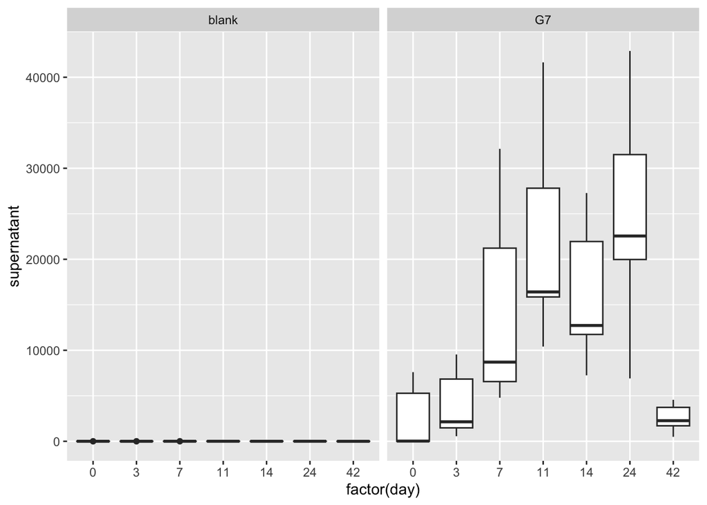

```r
#path to data
data_location <- here::here("data","pilotwide.xlsx")
pilotwide <- read_excel(data_location)

#blanks vs. treatment
ggplot(pilotwide, aes(factor(day), supernatant)) +
  geom_boxplot() + facet_wrap(~strain)
```

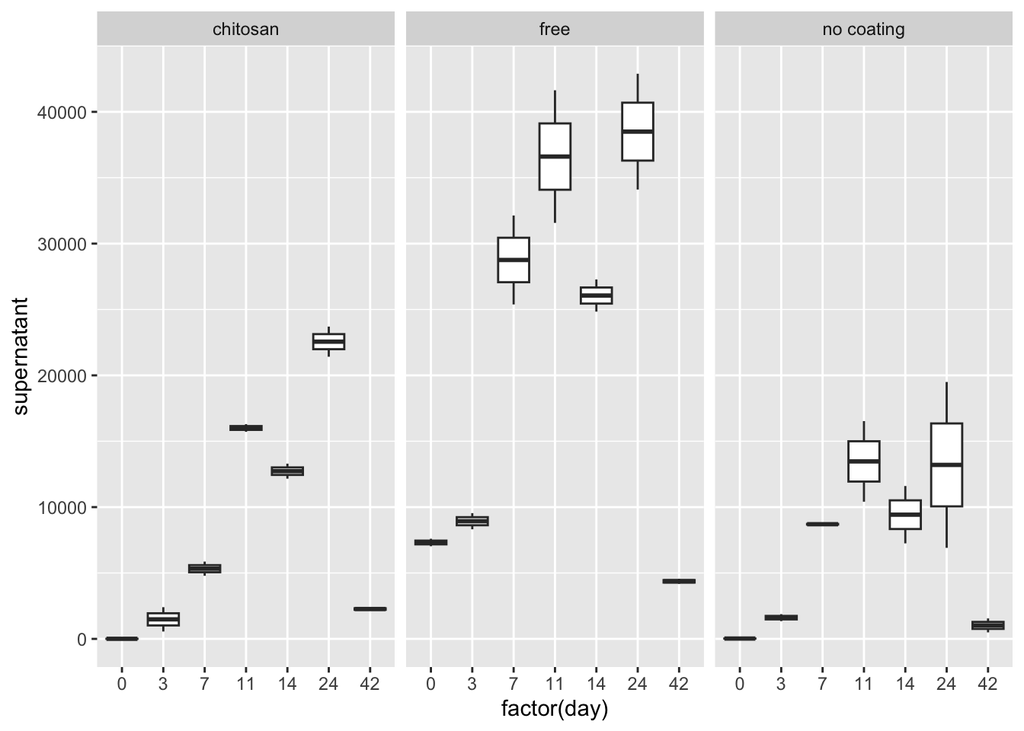

```r
#separate treatment groups from blanks
g7 <- pilotwide %>% filter(strain == "G7")
g7<- g7 %>% rename(reactor=reactor_no)

#boxplots over time for supernatant
ggplot(g7, aes(factor(day), supernatant)) +
  geom_boxplot() + facet_wrap(~coating)
```

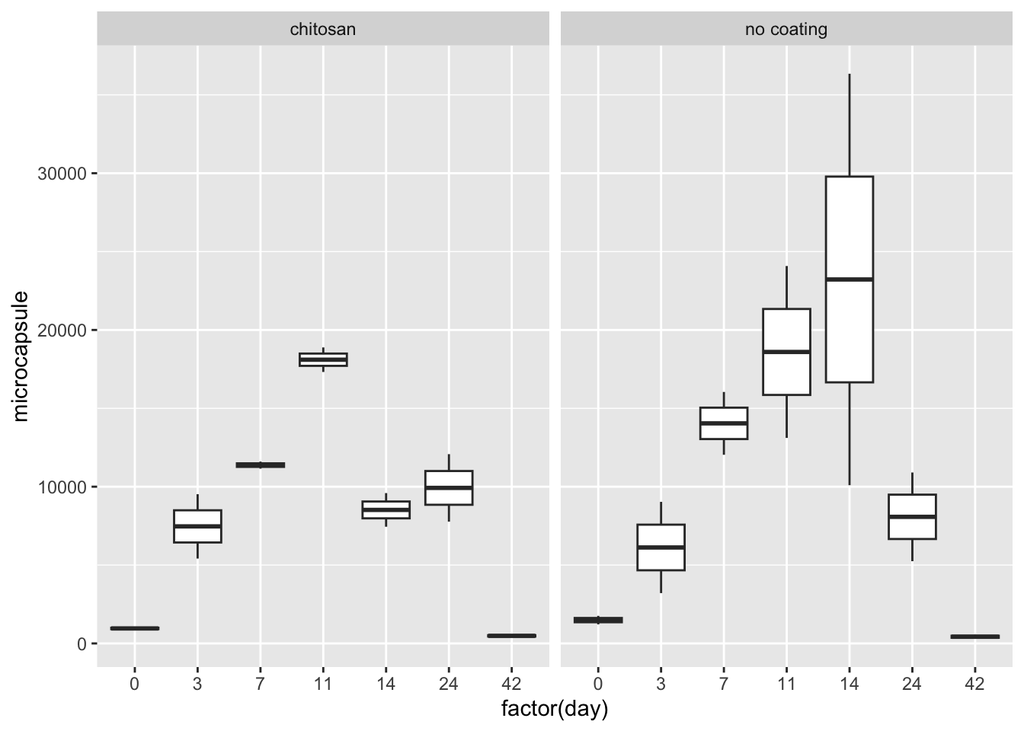

```r
#boxplots over time for microcapsule
capsule <- g7 %>% filter(treatment == "capsule")
ggplot(capsule, aes(factor(day), microcapsule)) +
  geom_boxplot() + facet_wrap(~coating)
```

```r
#supernatant stats
group_by(g7, coating) %>%
  summarise(mean = mean(supernatant, na.rm = TRUE),
                                    sd = sd(supernatant, na.rm = TRUE))
```

```
## # A tibble: 3 × 3
##   coating      mean     sd
##   <chr>       <dbl>  <dbl>
## 1 chitosan    8625.  8274.
## 2 free       21505. 14149.
## 3 no coating  6780.  6279.
```

```r
#microcapsule stats
group_by(capsule, coating) %>%
  summarise(mean = mean(microcapsule, na.rm = TRUE),
            sd = sd(microcapsule, na.rm = TRUE))
```

```
## # A tibble: 2 × 3
##   coating      mean     sd
##   <chr>       <dbl>  <dbl>
## 1 chitosan    8118.  6005.
## 2 no coating 10281. 10155.
```

```r
#these stats are misleading because they average across days of the entire experiment, so of course the sd is high.
#need to see it broken down by day
#supernatant stats
g7 %>% group_by(coating, day) %>%
  summarise(mean = mean(supernatant, na.rm = TRUE),
                                    sd = sd(supernatant, na.rm = TRUE))
```

```
## # A tibble: 21 × 4
## # Groups:   coating [3]
##    coating    day     mean       sd
##    <chr>    <dbl>    <dbl>    <dbl>
##  1 chitosan     0     5.78    0.309
##  2 chitosan     3  1482.   1307.
##  3 chitosan     7  5327.    763.
##  4 chitosan    11 16006.    410.
##  5 chitosan    14 12729     807.
##  6 chitosan    24 22558    1618.
##  7 chitosan    42  2266.    157.
##  8 free         0  7315.    402.
##  9 free         3  8931.    868.
## 10 free         7 28758.   4773.
## # ℹ 11 more rows
```

```r
#microcapsule stats
capsule %>% group_by(coating, day) %>%
  summarise(mean = mean(microcapsule, na.rm = TRUE),
            sd = sd(microcapsule, na.rm = TRUE))
```

```
## # A tibble: 14 × 4
## # Groups:   coating [2]
##    coating      day   mean     sd
##    <chr>      <dbl>  <dbl>  <dbl>
##  1 chitosan       0   956.   127.
##  2 chitosan       3  7468.  2903.
##  3 chitosan       7 11377    319.
##  4 chitosan      11 18102   1107.
##  5 chitosan      14  8519.  1518.
##  6 chitosan      24  9923.  3044.
##  7 chitosan      42   484.   120.
##  8 no coating     0  1488.   384.
##  9 no coating     3  6122.  4117.
## 10 no coating     7 14040.  2834.
## 11 no coating    11 18596.  7756.
## 12 no coating    14 23221. 18563.
## 13 no coating    24  8077.  4002.
## 14 no coating    42   426.   185.
```

```r
#let's visualize this with a graph
#for this, we need to make a dataframe with avg and sd
#by taking avg and sd, we assume this data is normal. Let's check that
#normality test
g7 %>% shapiro_test(supernatant) #overall, the data is NOT normal
```

```
## # A tibble: 1 × 3
##   variable    statistic        p
##   <chr>           <dbl>    <dbl>
## 1 supernatant     0.874 0.000264
```

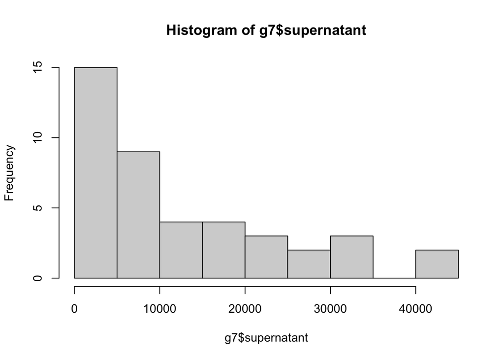

```r
hist(g7$supernatant)
```

```r
g7 %>% group_by(day) %>% shapiro_test(supernatant) #grouping by day and coating means sample size is less than 3 and test can't be run
```

```
## # A tibble: 7 × 4
##     day variable    statistic       p
##   <dbl> <chr>           <dbl>   <dbl>
## 1     0 supernatant     0.660 0.00227
## 2     3 supernatant     0.804 0.0638
## 3     7 supernatant     0.800 0.0589
## 4    11 supernatant     0.845 0.142
## 5    14 supernatant     0.862 0.197
## 6    24 supernatant     0.972 0.904
## 7    42 supernatant     0.939 0.651
```

```r
#within days, data IS normal except for day 0
g7 %>% group_by(coating) %>% shapiro_test(supernatant) #normal for each group
```

```
## # A tibble: 3 × 4
##   coating    variable    statistic      p
##   <chr>      <chr>           <dbl>  <dbl>
## 1 chitosan   supernatant     0.878 0.0544
## 2 free       supernatant     0.882 0.0614
## 3 no coating supernatant     0.899 0.108
```

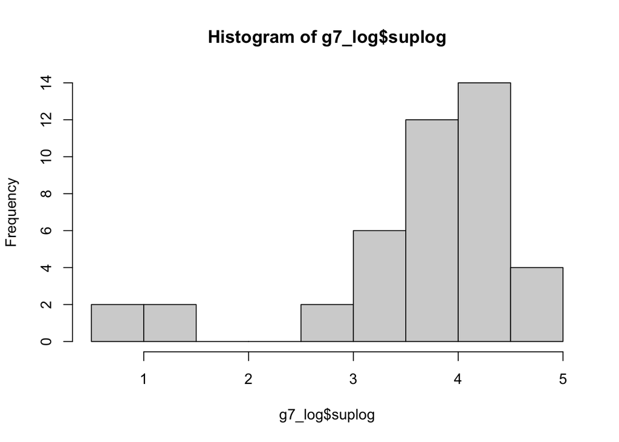

```r
#should we log transform to make data normal overall?
g7_log<- g7
g7_log$suplog<- log10(g7_log$supernatant)
g7_log$microlog<- log10(g7_log$microcapsule)
hist(g7_log$suplog)
```

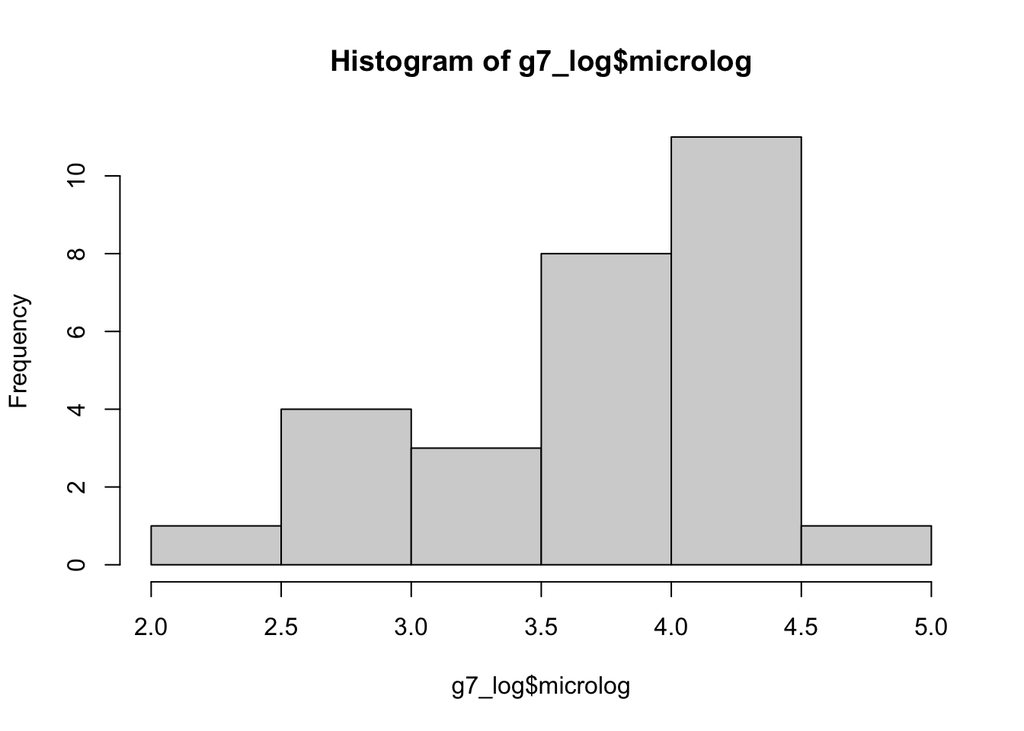

```r
hist(g7_log$microlog)
```

```r
shapiro.test(g7_log$suplog)
```

```
##
##  Shapiro-Wilk normality test
##
## data:  g7_log$suplog
## W = 0.77988, p-value = 1.695e-06
```

```r
shapiro.test(g7_log$microlog)
```

```
##
##  Shapiro-Wilk normality test
##
## data:  g7_log$microlog
## W = 0.88339, p-value = 0.004775
```

```r
#still not normal.
```

With the small sample size of the experiment and the lack of normality, can I do parametric tests here? #visualizing

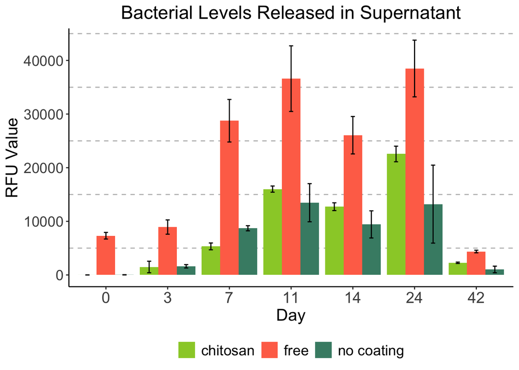

```r
data_location <- here::here("data","pilotsum.xlsx")
summ <- read_excel(data_location)

microcapsule<- summ %>% filter(type == "microcapsule") %>% filter(meas == "mScarlet")
supernatant<- summ %>% filter(type == "supernatant") %>% filter(meas == "mScarlet")
sample<- microcapsule %>% filter(strain == "G7")

#add grouped bar chart for supernatant
super<- supernatant %>% filter(strain == "G7")
ggplot(super, aes(fill=coating, y=avg_rfu, x = as.factor(day))) +
  geom_bar(position="dodge", stat="identity")+
geom_errorbar(aes(ymin=avg_rfu-sd, ymax=avg_rfu+sd), width=.2,
              position=position_dodge(.9))+
  theme_classic() +
  xlab("Day") +
  ylab("RFU Value")+
  theme(axis.text.x=element_text(angle = 0, hjust = .5, size = 15),
        axis.title = element_text(size = 16),
        axis.text.y = element_text(size = 14),
        legend.title = element_blank(),
        legend.text = element_text(size = 14),
        plot.title = element_text(size = 18, hjust = 0.5),
        legend.position = "bottom",
        panel.grid.minor.y = element_line(color = "grey",
                                          linetype = "dashed")) +
  ggtitle("Bacterial Levels Released in Supernatant")+
  theme(strip.text = element_text(
    size = 14)) +
  scale_fill_manual(values = c("no coating" = "aquamarine4",
                                "chitosan" = "olivedrab3",
                                "free" = "coral1"))+
  scale_x_discrete(breaks=c(0,3,7,11,14,24,42))
```

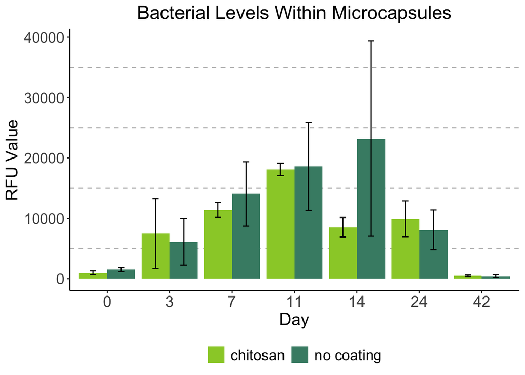

```r
#add grouped bar chart for within microcapsules
sample<- microcapsule %>% filter(strain == "G7")
ggplot(sample, aes(fill=coating, y=avg_rfu, x = as.factor(day))) +
  geom_bar(position="dodge", stat="identity")+
  geom_errorbar(aes(ymin=avg_rfu-sd, ymax=avg_rfu+sd), width=.2,
                position=position_dodge(.9))+
  theme_classic() +
  xlab("Day") +
  ylab("RFU Value")+
  theme(axis.text.x=element_text(angle = 0, hjust = .5, size = 15),
        axis.title = element_text(size = 16),
        axis.text.y = element_text(size = 14),
        legend.title = element_blank(),
        legend.text = element_text(size = 14),
        plot.title = element_text(size = 18, hjust = 0.5),
        legend.position = "bottom",
        panel.grid.minor.y = element_line(color = "grey",
                                          linetype = "dashed")) +
  ggtitle("Bacterial Levels Within Microcapsules")+
  theme(strip.text = element_text(
    size = 14)) +
  scale_fill_manual(values = c("no coating" = "aquamarine4",
                               "chitosan" = "olivedrab3",
                               "free" = "coral1"))+
  scale_x_discrete(breaks=c(0,3,7,11,14,24,42))
```

#ANOVAs

```r
g7_mod <- g7 %>% dplyr::select(day, coating, reactor, supernatant)
anova_test(data=g7_mod, dv=supernatant, wid=reactor, within="day", between="coating")
```

```
## ANOVA Table (type II tests)
##
##        Effect DFn DFd      F        p p<.05   ges
## 1     coating   2   3 48.892 5.00e-03     * 0.887
## 2         day   6  18 54.482 1.44e-10     * 0.932
## 3 coating:day  12  18  5.183 9.42e-04     * 0.724
```

```r
#all effects significant

#need to look at effect of treatment!
g7_mod2 <- g7 %>% dplyr::select(day, coating, reactor, supernatant, treatment)
anova_test(data=g7_mod2, dv=supernatant, wid=reactor, within="day", between="treatment")
```

```
## ANOVA Table (type III tests)
##
##          Effect DFn DFd      F        p p<.05   ges
## 1     treatment   1   4 89.909 6.90e-04     * 0.836
## 2           day   6  24 53.640 9.94e-13     * 0.912
## 3 treatment:day   6  24  7.587 1.21e-04     * 0.594
```

```r
#yes, significant effect of treatment, day, and treatment*day

cap_sup<- capsule %>% dplyr::select(day, coating, reactor, microcapsule, supernatant) %>% na.omit()
capsule_mod <- capsule %>% dplyr::select(day, coating, reactor, microcapsule)
anova_test(data=capsule_mod, dv=microcapsule, wid=reactor, within="day", between="coating")
```

```
## ANOVA Table (type II tests)
##
##        Effect DFn DFd     F     p p<.05   ges
## 1     coating   1   2 0.482 0.559       0.065
## 2         day   6  12 6.917 0.002     * 0.710
## 3 coating:day   6  12 1.185 0.377       0.296
```

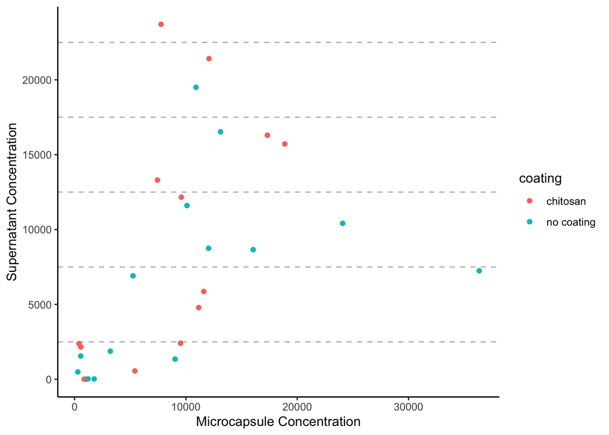

```r
#sig effect of day on bacteria level in capsule (no effect of coating)

#does microcapsule concentration impact supernatant?
#anova_test(data=cap_sup, dv=supernatant, wid=reactor, within=c("day","microcapsule"), between="coating") #think this is not working because microcapsule is numerical and R can't "divide" into groups based on those values
#need a different statistical test to answer this question

#visualize microcapsule concentration vs supernatant concentration
ggplot(data = cap_sup, aes(x = microcapsule, y = supernatant, color = coating)) +
  geom_point() + theme_classic() + xlab("Microcapsule Concentration") + ylab("Supernatant Concentration") +
  theme(panel.grid.minor.y = element_line(color = "grey", linetype = "dashed"))
```

Want to do some sort of regression to assess this relationship. But again, unsure about normality/linearity

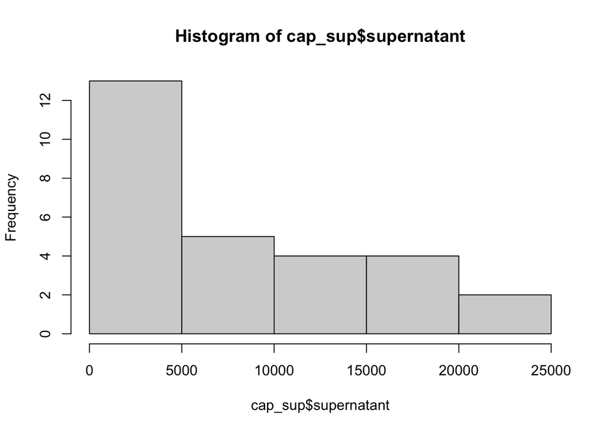

```r
hist(cap_sup$supernatant) #does not look normal. use spearman rank correlation?
```

```r
shapiro_test(cap_sup$supernatant) #not normal
```

```
## # A tibble: 1 × 3
##   variable            statistic p.value
##   <chr>                   <dbl>   <dbl>
## 1 cap_sup$supernatant     0.893 0.00801
```

```r
shapiro_test(cap_sup$microcapsule) #not normal
```

```
## # A tibble: 1 × 3
##   variable             statistic p.value
##   <chr>                    <dbl>   <dbl>
## 1 cap_sup$microcapsule     0.872 0.00264
```

```r
#NOT NORMAL
```

#nonporametric

```r
#Spearman's rank correlation
result2<- cor.test(cap_sup$microcapsule, cap_sup$supernatant, method = "spearman")
result2
```

```
##
##  Spearman's rank correlation rho
##
## data:  cap_sup$microcapsule and cap_sup$supernatant
## S = 1132, p-value = 7.413e-05
## alternative hypothesis: true rho is not equal to 0
## sample estimates:
##       rho
## 0.6902025
```

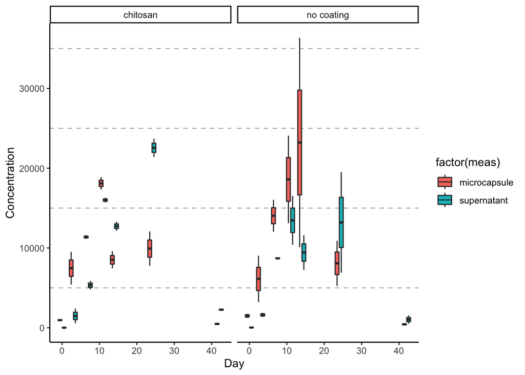

```r
#strong relationship between concentration of microcapsule and concentration of supernatant

#day vs concentration, show capsule and supernatant
cap_sup_long<- gather(cap_sup, meas, value, microcapsule:supernatant, factor_key=TRUE)
ggplot(data = cap_sup_long) +
  geom_boxplot(aes(x=day, y=value, group=interaction(day, meas), fill=factor(meas))) + theme_classic() + xlab("Day") + ylab("Concentration") +
  theme(panel.grid.minor.y = element_line(color = "grey", linetype = "dashed")) + facet_wrap(~coating)
```

# Diving deeper

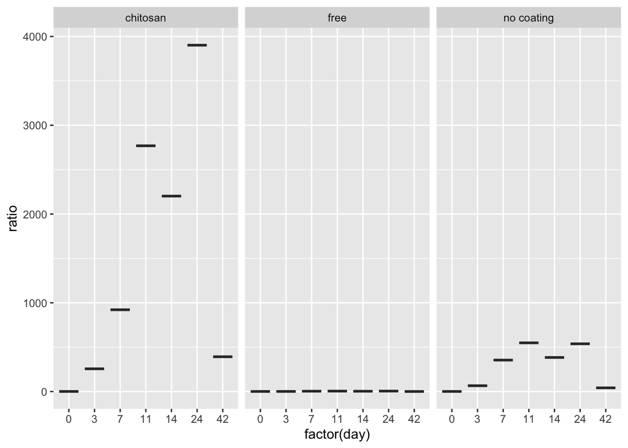

```r
#Boxplots of g7 show that free vs capsule treatments have different initial values. What if we normalize to day 0 in order to compare? This would also account for difference due to using sodium citrate to dissolve microcapsules
#look at super and sample, which have average and sd values
sup_n<- super
chit<- sup_n %>% filter(coating == "chitosan")
alg<- sup_n %>% filter(coating == "no coating")
free<- sup_n %>% filter(coating == "free")

chit$initial <- 5.78125
alg$initial <- 24.54700
free$initial <- 7315.25000

all<- bind_rows(chit, alg, free)
all$ratio<- all$avg_rfu/all$initial
all$logratio<- log10(all$ratio)

#boxplots over time for supernatant
ggplot(all, aes(factor(day), ratio)) +
  geom_boxplot() + facet_wrap(~coating)
```

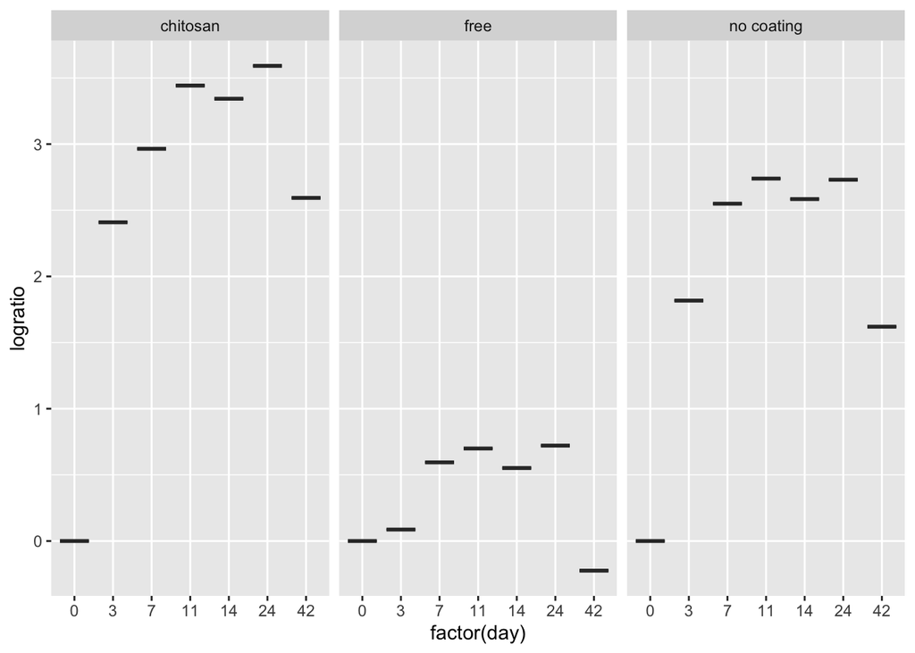

```r
ggplot(all, aes(factor(day), logratio)) +
  geom_boxplot() + facet_wrap(~coating) #think this is the correct way to present the data
```

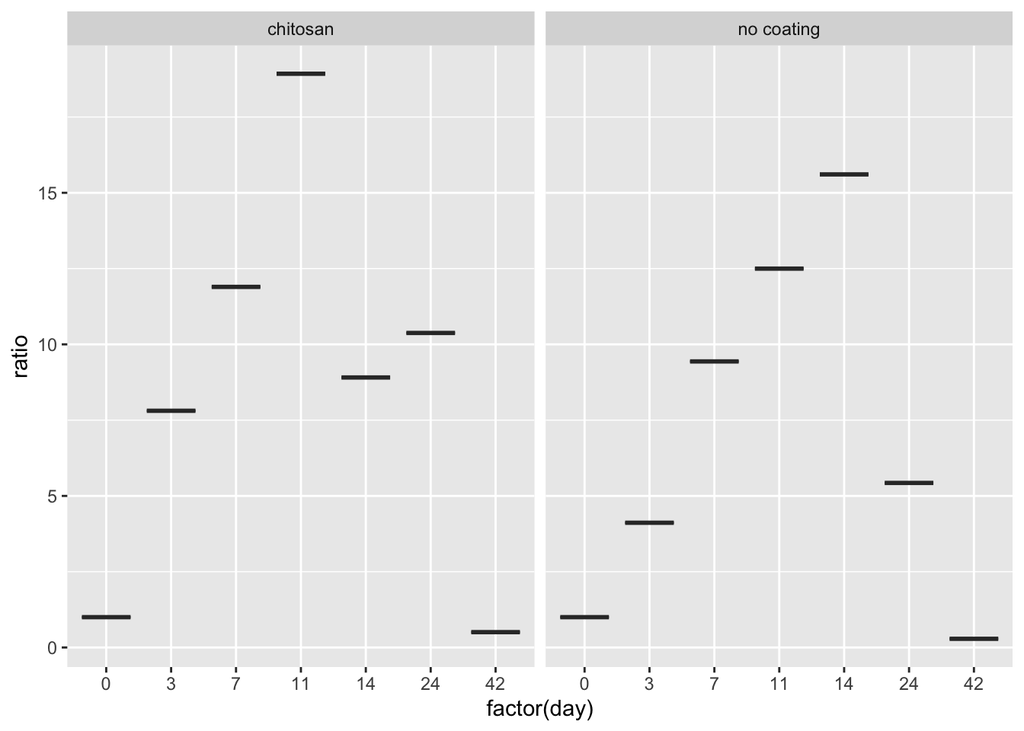

```r
#let's try with microcapsule data
micro_n<- sample
chitm<- micro_n %>% filter(coating == "chitosan")
algm<- micro_n %>% filter(coating == "no coating")

chitm$initial <- 956.3750
algm$initial <- 1487.8750

allm<- bind_rows(chitm, algm)
allm$ratio<- allm$avg_rfu/allm$initial
allm$logratio<- log10(allm$ratio)

ggplot(allm, aes(factor(day), ratio)) +
  geom_boxplot() + facet_wrap(~coating)
```

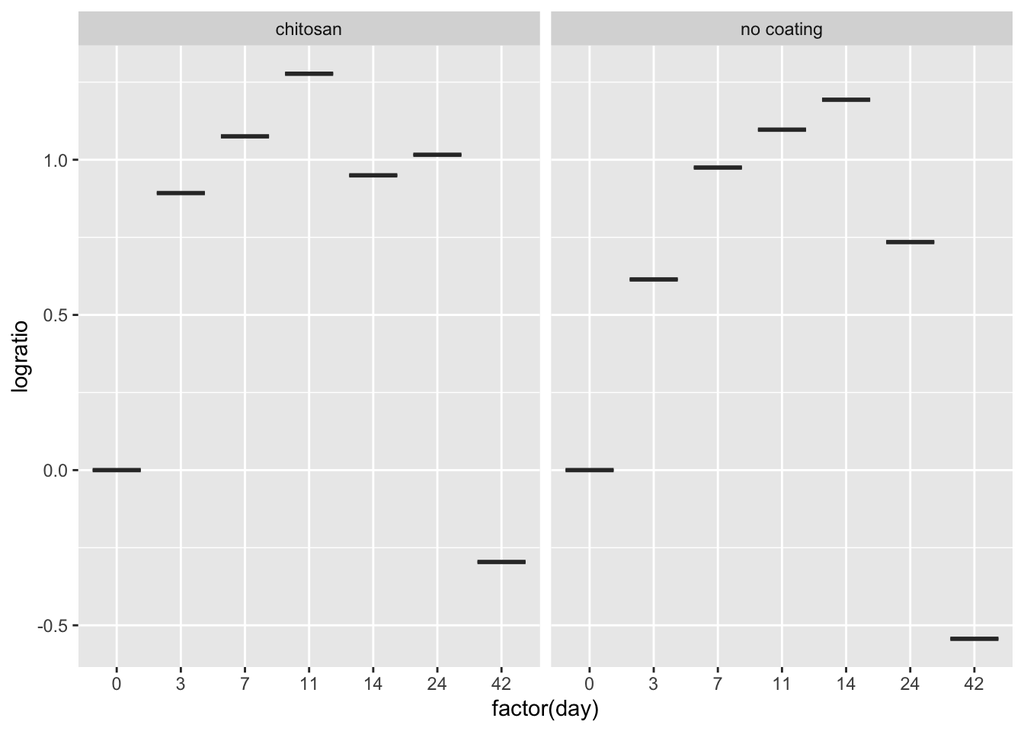

```r
ggplot(allm, aes(factor(day), logratio)) +
  geom_boxplot() + facet_wrap(~coating)
```

This tells us that the increase in supernatant bacterial levels relative to day 0 is greater for the microcapsules rather than free bacteria (because free bacteria start with higher initial level) - what does presenting the data in this way mean? is it biologically relevant? it also shows that the capsules help maintain a higher relative level by day 42, compared to free (which we do care about). Basically, demonstrates that capsule is acting as a release vehicle, whereas free is instant delivery - IMPLICATION of day 42 - still need to rerun stats on ratio